# Loyalty Program Effects with Causal Inference

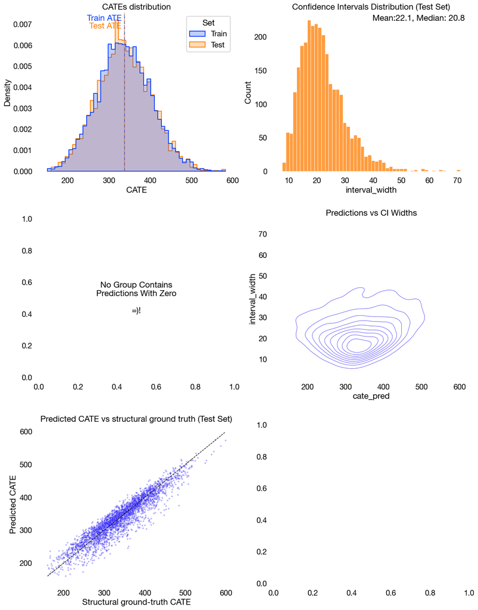

```python
evaluate_cates(ldml, X_train=X_train, X_test=X_test)
```

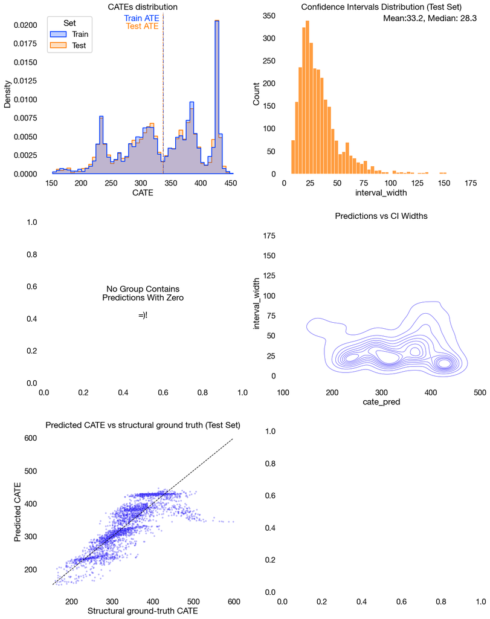

```python
evaluate_cates(fdr, X_train=X_train, X_test=X_test)
```

Now that we've added the mediator, we can see that all models recover an ATE closer to the DGP for the effect subscription only, and that the performance of all models (nuisance and EconML) has improved. There is still an important level of noise/error, but that is by design, and the CATE models do not capture this noise. Once again the infamous question: what model to use? I mentioned above that the choice also depends on what SHAP values you might want to deal with -- SHAP values from flexible models tend to be richer and capture more complex relationships, compared to a linear model, for example.

So below you can see the SHAP implementation for the three models explored so far, and how they differ in some basic outputs (scatter/dependence, and summary plots).

```python
def cate_shap(estimator=None):
    def cate_fn(X):
        return estimator.effect(X)
    return cate_fn

background = shap.sample(X_train, 700, random_state=0)

explainer_est = shap.Explainer(cate_shap(est), background)
est_shap_vals = explainer_est(X_test)
```

```
ExactExplainer explainer: 3001it [10:15,  4.80it/s]
```

```python
explainer_ldml = shap.Explainer(cate_shap(ldml), background)
ldml_shap_vals = explainer_ldml(X_test)
```

```python
explainer_fdr = shap.Explainer(cate_shap(fdr), background)
fdr_shap_vals = explainer_fdr(X_test)
```

```
ExactExplainer explainer: 3001it [09:16,  5.29it/s]
```

```
CausalForestDML:
```

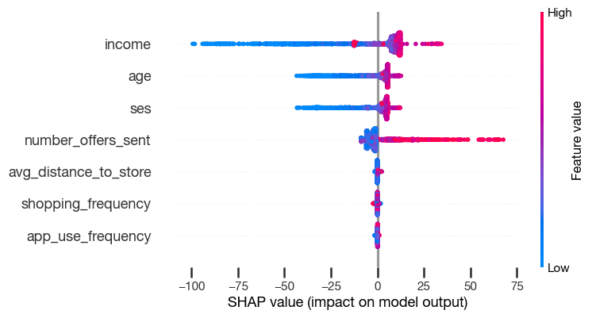

```
########################################

LinearDRLearner:
```

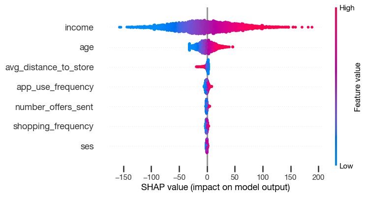

```
########################################

CausalForestDML:
```

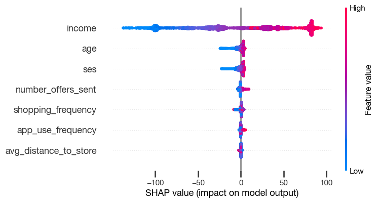

```
########################################
```

```python
models = ['CausalForestDML', 'LinearDRLearner', 'CausalForestDML']
shap_vals = [est_shap_vals, ldml_shap_vals, fdr_shap_vals]

for model, vals in zip(models, shap_vals):
    print(f'{model}:')
    shap.summary_plot(vals)
    print('#'*40, '\n')
```

```
CausalForestDML:
```

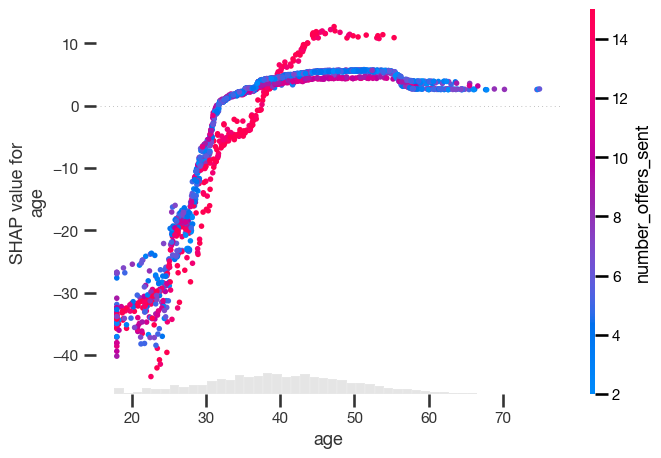

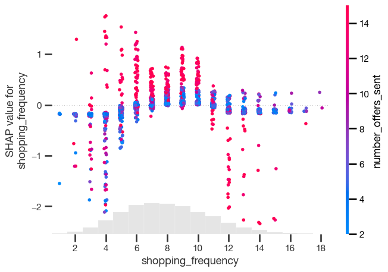

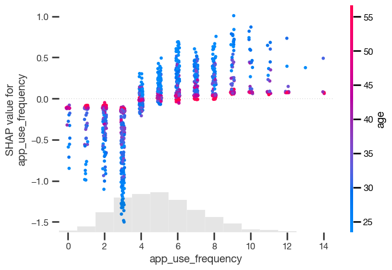

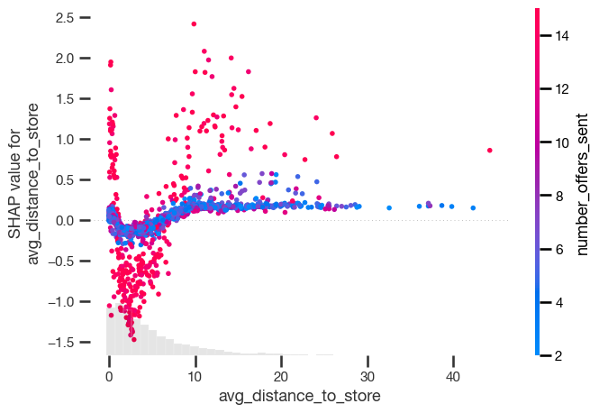

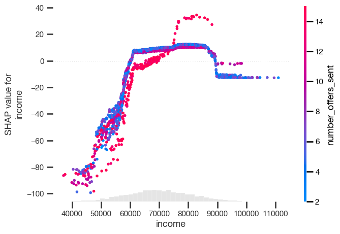

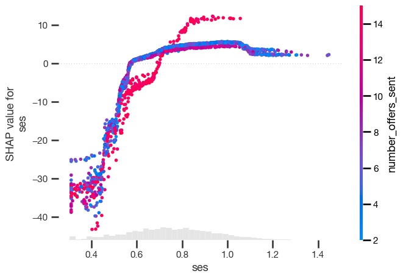

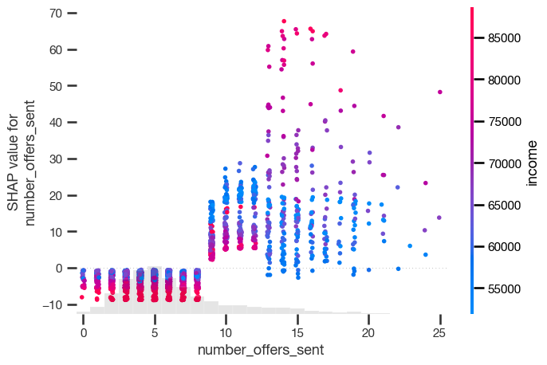

```
########################################

LinearDRLearner:
```

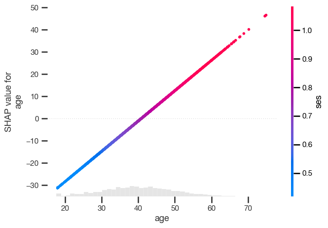

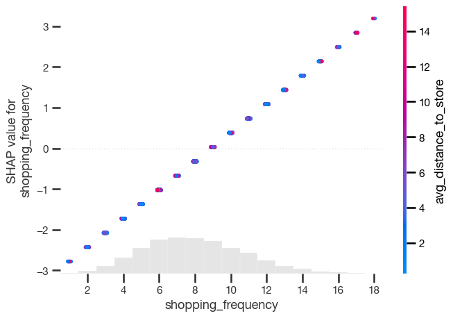

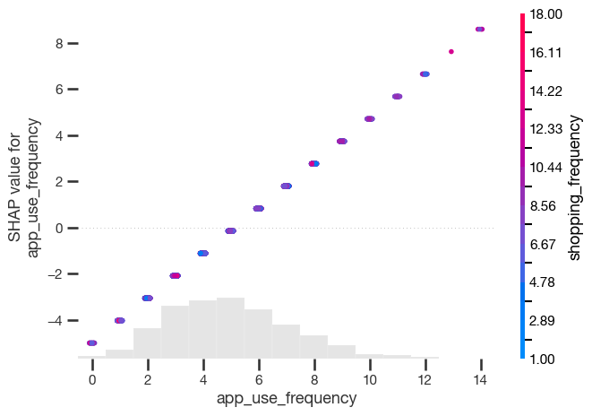

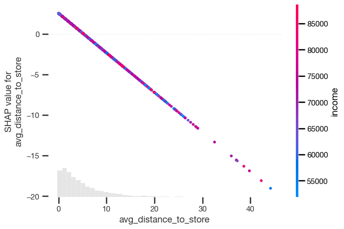

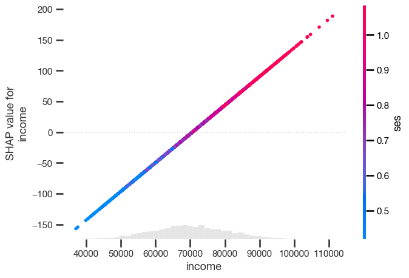

[9 more figures not shown]

```
########################################
```

```python
for model, vals in zip(models, shap_vals):
    print(f'{model}: ')
    for col in X_test.columns.tolist():
        shap.plots.scatter(vals[:, col], color=vals)
    print('#'*40, '\n')
```

What do the SHAP values show? In the case of EconML, and provided the background data we provided as sample is representative of the larger dataframe, these SHAP values show *what is the uplift driven by the relevant feature x distribution interaction compared to the ATE* (the zero line in each feature). So this is different to what we usually see with SHAP values applied to other ML problems. In a classic ML problem predicting sales, a positive linear relationship between income and SHAP values for income could be interpreted as "higher income increases sales or predicts higher sales". Here, the interpretation would be "those with higher income are predicted to have a higher conditional effect as a consequence of the treatment". Differently put, that higher sales should come from converting higher income people into the subscription.

So that gives us the basis to create some further segmentation based not only on the features above, but also leveraging the CATEs produced by the model we choose in the end.

Thanks for reading!